# AllLifeBankCustomerSegmentation

#### Cluster Profiling

```python
cluster_profile = df.groupby("K_means_segments").mean()
```

```python
cluster_profile["count_in_each_segments"] = (
    df.groupby("K_means_segments")["Total_Credit_Cards"].count().values
)
```

```python
# let's display cluster profiles
cluster_profile.style.highlight_max(color="lightgreen", axis=0)
```

| K_means_segments | Avg_Credit_Limit | Total_Credit_Cards | Total_visits_bank | Total_visits_online | Total_calls_made | count_in_each_segments |
| --- | --- | --- | --- | --- | --- | --- |
| 0 | 33782.383420 | 5.515544 | 3.489637 | 0.981865 | 2.000000 | 386 |
| 1 | 12174.107143 | 2.410714 | 0.933036 | 3.553571 | 6.870536 | 224 |
| 2 | 141040.000000 | 8.740000 | 0.600000 | 10.900000 | 1.080000 | 50 |

#### Insights for K_means_Segments

- Cluster 0:
  - Avg_Credit_Limit is moderate.
  - Total_credit_cards holding by customers are around 5~6
  - Total_visits_bank is also modetate around 3~4 per year.
  - Visits_Online is less than 1 for this segment of customers.
  - Total_calls_made is around 2 per year.
- Cluster 1:
  - Avg_Credit_Limit is low compared to other segments.
  - Total_credit_cards are also low around 2~3
  - Total_visits_bank is significantly low < 1.
  - Visits_Online is around 3~4 per year
  - Total_calls_made is high for this segment custoemrs.
- Cluster 2:
  - Avg_Credit_Limit is very high for this segment customers.
  - Total_credit_cards holding also high aroung 8~9.
  - Total_visits_bank is very low < 1.
  - Visits_Online is high around 10~11 per year
  - Total_calls_made is low around 1

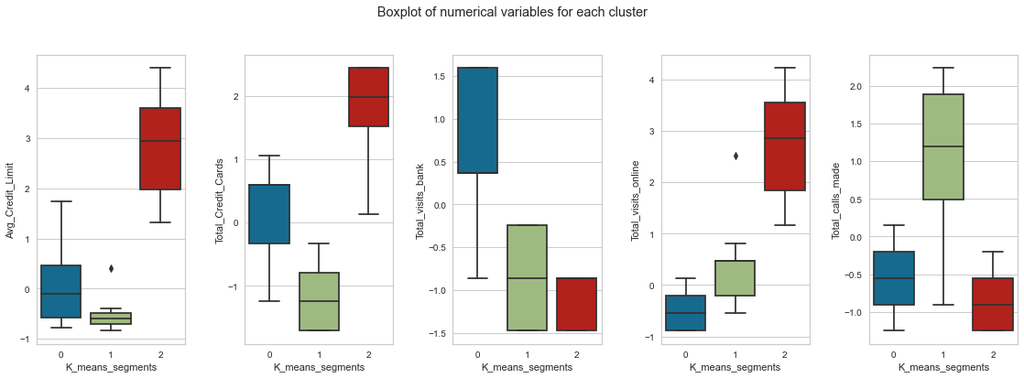

```python
fig, axes = plt.subplots(1, 5, figsize=(16, 6))
fig.suptitle("Boxplot of numerical variables for each cluster")
counter = 0
for ii in range(5):
    sns.boxplot(
        ax=axes[ii],
        y=subset_scaled_df[num_col[counter]],
        x=subset_scaled_df["K_means_segments"],
    )
    counter = counter + 1

fig.tight_layout(pad=2.0)
```

- Box plot also showed same details those I mentioned 'Insights for K_means_Segments'

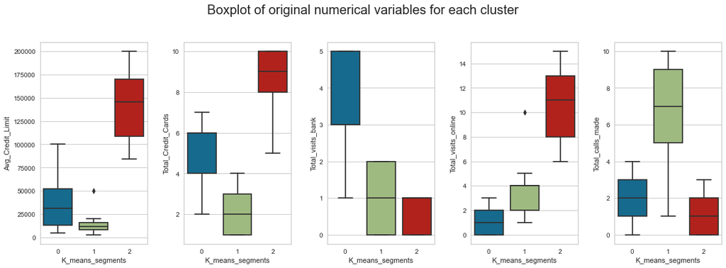

```python
fig, axes = plt.subplots(1, 5, figsize=(16, 6))
fig.suptitle("Boxplot of original numerical variables for each cluster", fontsize=20)
counter = 0
for ii in range(5):
    sns.boxplot(ax=axes[ii], y=df[num_col[counter]], x=df["K_means_segments"])
    counter = counter + 1

fig.tight_layout(pad=2.0)
```

- Box plot for actual data showed identical details as in scaled data with k_means clustering

#### Insights

- Comparing each Cluster with total_credit_cards owned by the customers.

```python
pd.crosstab(df.K_means_segments, df.Total_Credit_Cards).style.highlight_max(
    color="lightgreen", axis=0
)
```

| Total_Credit_Cards K_means_segments | 1 | 2 | 3 | 4 | 5 | 6 | 7 | 8 | 9 | 10 |
| --- | --- | --- | --- | --- | --- | --- | --- | --- | --- | --- |
| 0 | 0 | 1 | 0 | 102 | 73 | 116 | 94 | 0 | 0 | 0 |
| 1 | 59 | 63 | 53 | 49 | 0 | 0 | 0 | 0 | 0 | 0 |
| 2 | 0 | 0 | 0 | 0 | 1 | 1 | 7 | 11 | 11 | 19 |

### Hierarchical Clustering

```python
# list of distance metrics
distance_metrics = ["euclidean", "chebyshev", "mahalanobis", "cityblock"]

# list of linkage methods
linkage_methods = ["single", "complete", "average", "weighted"]

high_cophenet_corr = 0
high_dm_lm = [0, 0]

for dm in distance_metrics:
    for lm in linkage_methods:
        Z = linkage(subset_scaled_df, metric=dm, method=lm)
        c, coph_dists = cophenet(Z, pdist(subset_scaled_df))
        print(
            "Cophenetic correlation for {} distance and {} linkage is {}.".format(
                dm.capitalize(), lm, c
            )
        )
        if high_cophenet_corr < c:
            high_cophenet_corr = c
            high_dm_lm[0] = dm
            high_dm_lm[1] = lm
```

```
Cophenetic correlation for Euclidean distance and single linkage is 0.8788676940541079.
Cophenetic correlation for Euclidean distance and complete linkage is 0.8860521900934342.
Cophenetic correlation for Euclidean distance and average linkage is 0.9168725782090766.
Cophenetic correlation for Euclidean distance and weighted linkage is 0.9133393931042242.
Cophenetic correlation for Chebyshev distance and single linkage is 0.8978014062578786.
Cophenetic correlation for Chebyshev distance and complete linkage is 0.8623270916886306.
Cophenetic correlation for Chebyshev distance and average linkage is 0.9160784250471772.
Cophenetic correlation for Chebyshev distance and weighted linkage is 0.9109044268579872.
Cophenetic correlation for Mahalanobis distance and single linkage is 0.8959952526724231.
Cophenetic correlation for Mahalanobis distance and complete linkage is 0.6550023123197843.
Cophenetic correlation for Mahalanobis distance and average linkage is 0.8467618899578893.
Cophenetic correlation for Mahalanobis distance and weighted linkage is 0.8207917162822882.
Cophenetic correlation for Cityblock distance and single linkage is 0.8406488764445825.
Cophenetic correlation for Cityblock distance and complete linkage is 0.8890360877047411.
Cophenetic correlation for Cityblock distance and average linkage is 0.9149250127652871.
Cophenetic correlation for Cityblock distance and weighted linkage is 0.8901622514742297.
```

```python
# printing the combination of distance metric and linkage method with the highest cophenetic correlation
print(
    "Highest cophenetic correlation is {}, which is obtained with {} distance and {} linkage.".format(
        high_cophenet_corr, high_dm_lm[0].capitalize(), high_dm_lm[1]
    )
)
```

```
Highest cophenetic correlation is 0.9168725782090766, which is obtained with Euclidean distance and average linkage.
```

##### Exploring different linkage methods with Euclidean distance only.

```python
# list of linkage methods
linkage_methods = ["single", "complete", "average", "centroid", "ward", "weighted"]

high_cophenet_corr = 0
high_dm_lm = [0, 0]

for lm in linkage_methods:
    Z = linkage(subset_scaled_df, metric="euclidean", method=lm)
    c, coph_dists = cophenet(Z, pdist(subset_scaled_df))
    print("Cophenetic correlation for {} linkage is {}.".format(lm, c))
    if high_cophenet_corr < c:
        high_cophenet_corr = c
        high_dm_lm[0] = "euclidean"
        high_dm_lm[1] = lm
```

```
Cophenetic correlation for single linkage is 0.8788676940541079.
Cophenetic correlation for complete linkage is 0.8860521900934342.
Cophenetic correlation for average linkage is 0.9168725782090766.
Cophenetic correlation for centroid linkage is 0.9134704636213649.
Cophenetic correlation for ward linkage is 0.774233615737438.
Cophenetic correlation for weighted linkage is 0.9133393931042242.
```

```python
# printing the combination of distance metric and linkage method with the highest cophenetic correlation
print(
    "Highest cophenetic correlation is {}, which is obtained with {} linkage.".format(
        high_cophenet_corr, high_dm_lm[1]
    )
)
```

```
Highest cophenetic correlation is 0.9168725782090766, which is obtained with average linkage.
```

#### Observations

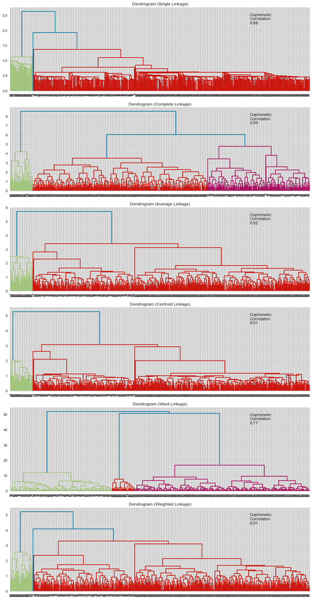

```python
# list of linkage methods
linkage_methods = ["single", "complete", "average", "centroid", "ward", "weighted"]

# lists to save results of cophenetic correlation calculation
compare_cols = ["Linkage", "Cophenetic Coefficient"]
compare = []

# to create a subplot image
fig, axs = plt.subplots(len(linkage_methods), 1, figsize=(15, 30))

# We will enumerate through the list of linkage methods above
# For each linkage method, we will plot the dendrogram and calculate the cophenetic correlation
for i, method in enumerate(linkage_methods):
    Z = linkage(subset_scaled_df, metric="euclidean", method=method)

    dendrogram(Z, ax=axs[i])
    axs[i].set_title(f"Dendrogram ({method.capitalize()} Linkage)")

    coph_corr, coph_dist = cophenet(Z, pdist(subset_scaled_df))
    axs[i].annotate(
        f"Cophenetic\nCorrelation\n{coph_corr:0.2f}",
        (0.80, 0.80),
        xycoords="axes fraction",
    )

    compare.append([method, coph_corr])
```

Observations

- Dendrogram for Ward linkage shows distinct and separate clusters.

```python
# dataframe to compare cophenetic correlations for each linkage method
df_cc = pd.DataFrame(compare, columns=compare_cols)
df_cc
```

|  | Linkage | Cophenetic Coefficient |
| --- | --- | --- |
| 0 | single | 0.878868 |
| 1 | complete | 0.886052 |
| 2 | average | 0.916873 |
| 3 | centroid | 0.913470 |
| 4 | ward | 0.774234 |
| 5 | weighted | 0.913339 |

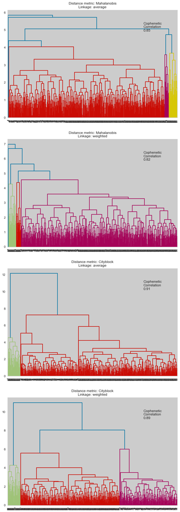

```python
# list of distance metrics
distance_metrics = ["Mahalanobis", "cityblock"]

# list of linkage methods
linkage_methods = ["average", "weighted"]

# to create a subplot image
fig, axs = plt.subplots(
    len(distance_metrics) + len(distance_metrics), 1, figsize=(10, 30)
)

i = 0
for dm in distance_metrics:
    for lm in linkage_methods:
        Z = linkage(subset_scaled_df, metric=dm, method=lm)

        dendrogram(Z, ax=axs[i])
        axs[i].set_title("Distance metric: {}\nLinkage: {}".format(dm.capitalize(), lm))

        coph_corr, coph_dist = cophenet(Z, pdist(subset_scaled_df))
        axs[i].annotate(
            f"Cophenetic\nCorrelation\n{coph_corr:0.2f}",
            (0.80, 0.80),
            xycoords="axes fraction",
        )
        i += 1
```

Observations

Out of all the dendrograms, it is clear that the dendrogram with Ward linkage gave a separate and distinct clusters. 3 would be the appropriate number of the clusters from the dendrogram with Ward linkage method.

- Creating 3 clusters.

```python
HCmodel = AgglomerativeClustering(n_clusters=3, affinity="euclidean", linkage="ward")
HCmodel.fit(subset_scaled_df)
```

```
AgglomerativeClustering(n_clusters=3)
```

```python
# adding hierarchical cluster labels to the original and scaled dataframes

subset_scaled_df["HC_Clusters"] = HCmodel.labels_
df["HC_Clusters"] = HCmodel.labels_
```

#### Cluster Profiling

```python
cluster_profile = df.groupby("HC_Clusters").mean()
```

```python
cluster_profile["count_in_each_segments"] = (
    df.groupby("HC_Clusters")["Total_Credit_Cards"].count().values
)
```

```python
# let's display cluster profiles
cluster_profile.style.highlight_max(color="lightgreen", axis=0)
```

| HC_Clusters | Avg_Credit_Limit | Total_Credit_Cards | Total_visits_bank | Total_visits_online | Total_calls_made | K_means_segments | count_in_each_segments |
| --- | --- | --- | --- | --- | --- | --- | --- |
| 0 | 33782.383420 | 5.515544 | 3.489637 | 0.981865 | 2.000000 | 0.000000 | 386 |
| 1 | 12174.107143 | 2.410714 | 0.933036 | 3.553571 | 6.870536 | 1.000000 | 224 |
| 2 | 141040.000000 | 8.740000 | 0.600000 | 10.900000 | 1.080000 | 2.000000 | 50 |

#### Insights for Hierarchical Clustering

- Cluster 0:
  - Avg_Credit_Limit is moderate.
  - Total_credit_cards holding by customers are around 5~6
  - Total_visits_bank is also modetate around 3~4 per year.
  - Visits_Online is less than 1 for this segment of customers.
  - Total_calls_made is around 2 per year.
- Cluster 1:
  - Avg_Credit_Limit is low compared to other segments.
  - Total_credit_cards are also low around 2~3
  - Total_visits_bank is also modetate significantly low < 1.
  - Visits_Online is around 3~4 per year
  - Total_calls_made is high for this segment custoemrs.
- Cluster 2:
  - Avg_Credit_Limit is very high for this segment customers.
  - Total_credit_cards holding also high aroung 8~9.
  - Total_visits_bank is also low < 1.
  - Visits_Online is high arounf 10~11 per year
  - Total_calls_made is low around 1

```python
cluster_profile["count_in_each_segments"] = (
    df.groupby("K_means_segments")["Total_Credit_Cards"].count().values
)
```

```python
# let's display cluster profiles
cluster_profile.style.highlight_max(color="lightgreen", axis=0)
```

| HC_Clusters | Avg_Credit_Limit | Total_Credit_Cards | Total_visits_bank | Total_visits_online | Total_calls_made | K_means_segments | count_in_each_segments |
| --- | --- | --- | --- | --- | --- | --- | --- |
| 0 | 33782.383420 | 5.515544 | 3.489637 | 0.981865 | 2.000000 | 0.000000 | 386 |
| 1 | 12174.107143 | 2.410714 | 0.933036 | 3.553571 | 6.870536 | 1.000000 | 224 |
| 2 | 141040.000000 | 8.740000 | 0.600000 | 10.900000 | 1.080000 | 2.000000 | 50 |

#### Comparing K_means and HC_Clusters (euclidean)

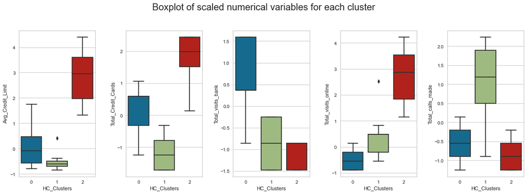

```python
fig, axes = plt.subplots(1, 5, figsize=(16, 6))
fig.suptitle("Boxplot of scaled numerical variables for each cluster", fontsize=20)
counter = 0
for ii in range(5):
    sns.boxplot(
        ax=axes[ii],
        y=subset_scaled_df[num_col[counter]],
        x=subset_scaled_df["HC_Clusters"],
    )
    counter = counter + 1

fig.tight_layout(pad=2.0)
```

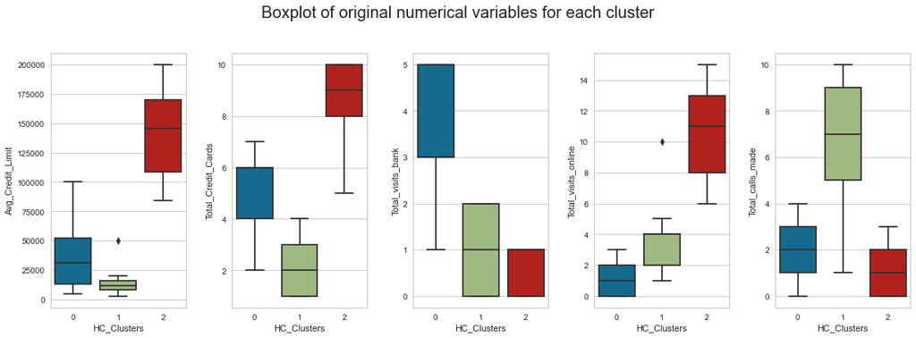

```python
fig, axes = plt.subplots(1, 5, figsize=(16, 6))
fig.suptitle("Boxplot of original numerical variables for each cluster", fontsize=20)
counter = 0
for ii in range(5):
    sns.boxplot(ax=axes[ii], y=df[num_col[counter]], x=df["HC_Clusters"])
    counter = counter + 1

fig.tight_layout(pad=2.0)
```

- Box plot for actual data showed identical details as in scaled data with Hiranchial clustering

#### Insights

- Compare Cluster vs Total_credit_cards owned by customers.

```python
pd.crosstab(df.HC_Clusters, df.Total_Credit_Cards).style.highlight_max(
    color="lightgreen", axis=0
)
```

| Total_Credit_Cards HC_Clusters | 1 | 2 | 3 | 4 | 5 | 6 | 7 | 8 | 9 | 10 |
| --- | --- | --- | --- | --- | --- | --- | --- | --- | --- | --- |
| 0 | 0 | 1 | 0 | 102 | 73 | 116 | 94 | 0 | 0 | 0 |
| 1 | 59 | 63 | 53 | 49 | 0 | 0 | 0 | 0 | 0 | 0 |
| 2 | 0 | 0 | 0 | 0 | 1 | 1 | 7 | 11 | 11 | 19 |

#### Observations

- The HC_clusters also showed same type of segmentation with credit cards.
- Since we noticed a significant outliers (Credit_limit), I want to check the results with Manhattan distance too.

```python
HCmodel = AgglomerativeClustering(n_clusters=3, affinity="cityblock", linkage="average")
HCmodel.fit(subset_scaled_df)
```

```
AgglomerativeClustering(affinity='cityblock', linkage='average', n_clusters=3)
```

```python
# adding hierarchical cluster labels to the original and scaled dataframes

subset_scaled_df["HC_Clusters"] = HCmodel.labels_
df["HC_Clusters"] = HCmodel.labels_
```

```python
#### Cluster Profiling
```

```python
cluster_profile = df.groupby("HC_Clusters").mean()
```

```python
cluster_profile["count_in_each_segments"] = (
    df.groupby("HC_Clusters")["Total_Credit_Cards"].count().values
)
```

```python
# let's display cluster profiles
cluster_profile.style.highlight_max(color="lightgreen", axis=0)
```

| HC_Clusters | Avg_Credit_Limit | Total_Credit_Cards | Total_visits_bank | Total_visits_online | Total_calls_made | K_means_segments | count_in_each_segments |
| --- | --- | --- | --- | --- | --- | --- | --- |
| 0 | 33782.383420 | 5.515544 | 3.489637 | 0.981865 | 2.000000 | 0.000000 | 386 |
| 1 | 141040.000000 | 8.740000 | 0.600000 | 10.900000 | 1.080000 | 2.000000 | 50 |
| 2 | 12174.107143 | 2.410714 | 0.933036 | 3.553571 | 6.870536 | 1.000000 | 224 |

#### Insights & Recommendations

- After evaluating both K_means and Hierarchical (euclidean), here are few insights and business recommendations:
- Cluster 2 consists of customers who have more credit cards and Avg_credit_limit. So focus marketing campaigns such that bank not only should retain these customers but also should sell products to other segment customers. Probably it may be better to get feedback from this cluster group and build marketting campaigns to attract new customers and upsell to other segment customers.
- Cluster 2 customers relay heavely on bank online facility compared to other communication channles like visting banks are calling them - They may be using for online payments or to chat with customer representatives. Bank should focus on improving the site and also make sure customers issues addressed in less time. This improves customer satisfaction.
- Cluster 1 customers have low avg_credit_limit and holding 2-3 credit cards compared to other segments. They are around 224 in count, they have been making calls 6-7 per year than using online (3-4 visits per year). Bank should focus on this area, they should conduct a survery or somemething to get the customers feedback from this segment. It is also better to encourage customers to use online. After customer feedback, bank should build a campign to attract new customers to this segment.
- Cluster 0 customers have moderately good avg_credit_limit with 5-6 credit cards. This segment customers spending with bank by making calls or visting bank than using online. Same points I recommended with cluster 1 should apply to this segment too.

#### Final Words (conclusions):

- The dataset has very limited data to draw conclusions. But what I have noticed is almost every customer reaching bank using one of the channel. Bank need to focus on this to imporve their services in order to cut down customer dissatisfaction. Bank should conduct customer survery, getting direct feedbank, run seasonal (festivel or holiday) promotions. This not only improves retaining existing customers but also improves banks overall service offering, that further leads to attract new customers and selling new products to existing customers.